# Importing database files into SPSS

Steve Simon

1999-08-18

**[StATS]:** **Importing database files into SPSS (created 1999-08-18)**

*Dear Professor Mean, How do I import database files into SPSS? I don't want to re-type everything, because there are 70,000 records. The data are stored in a Microsoft Access file. -- Vexed Vidya*

SPSS can import data from a variety of sources using a system known as ODBC (Object Data Base Connectivity). **ODBC has links to just about every database that you would ever need to use**.

**Short explanation**

I'll show you an example using Microsoft Access, but this would work just as well on other database systems, such as Oracle and Informix. **To import data from Access, select FILE | DATABASE CAPTURE | NEW QUERY from the SPSS menu.**

**More details**

After you specify the type of data you want to import, SPSS will ask you for the following details.

- Where the data are located
- The table or tables in your database you want to import

You also have the following options

- Specifying relationships between tables
- Selecting a subset of your data
- Renaming some of the variables
- Saving the query for re-use

**Saving the query for re-use is another way of simplifying repeated imports from the same data set**. Saving the query will save not only the location of hte database you want to import from, but also the information about subsets, changes in variable names, etc.

**Example**

[figure not shown]

[figure not shown]

**SPSS gives you a list of all available tables and queries within this database**.

[figure not shown]

**If you have a simple import, you can click on the FINISH button now**. If you click on the NEXT button instead, SPSS will give you some options to fine tune your import. You can

- Specifying relationships between tables
- Selecting a subset of your data
- Renaming some of the variables
- Saving the query for re-use

**Saving the query for re-use is another way of simplifying repeated imports from the same data set**. Saving the query will save not only the location of hte database you want to import from, but also the information about subsets, changes in variable names, etc.

**What should I do if Access files are not listed as a data source?**

[figure not shown]

[figure not shown]

In the ODBC DATA SOURCE ADMINISTRATOR dialog box, you want to add a new data source. Click on the ADD button. You also have the option of removing a data format you no longer need (REMOVE button), or changing some of the options in a data format you already have (CONFIGURE button). When you click on the ADD button, you get the following dialog box.

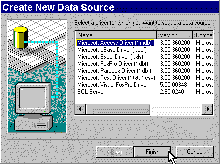

In the CREATE A NEW DATA SOURCE dialog box, you have a list of ODBC data sources which you can add to your system. Highlight the driver you want (in this case the Access driver) and click on the FINISH button.

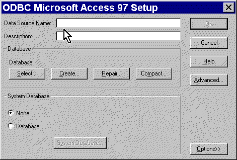

As the dialog box above shows, you're not quite finished yet. Tell the system a name and description for this format. A good name would be "Access files" and a good description would be "Microsoft Access 97 files (*.mdb)". If you repeatedly use the same database, you could even have the system select this database automatically (SELECT button). It's a good idea to set up a general driver first, so add a name and description and then click on the OK button.

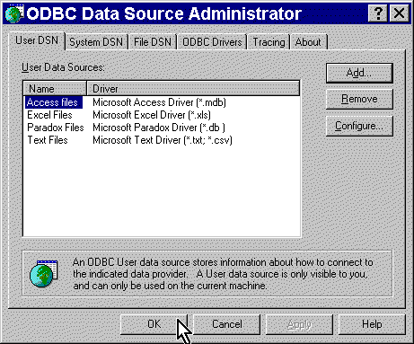

Now your dialog box has the format you need. Click on the OK button to finish up. This format will appear every time now when you run a database capture in SPSS.

**What should I do if I can't find the driver for Microsoft Access in the CREATE NEW DATA SOURCE dialog box?**

If you are still having problems please let me know. I can suggest several options that might work.

1. Call our tech support line and ask for help. Explain that your system does not have the ODBC drivers for Microsoft Access installed.
2. The CD ROM for SPSS has a special folder called ODBC Drivers. Find the file dataacc.exe and run it. I have this CD ROM and will be willing to help you get it running.
3. You can also go to http://www.microsoft.com/data/, the Microsoft Universal Data Access Web Site. Download the latest version of MDAC (Microsoft Data Access Components). I have not tried this, so I don't know how easy it is to install.
4. You might also find MDAC on the Microsoft Access or Microsoft Office CD-ROM.

There are some more details in some email messages that appeared on the SPSSX-L listserver on September 10-11, 2000.

**What if SPSS asks for a password?**

On some systems, SPSS will ask you for a password, even when the database you are trying to import does not have a password. There are several ways to work around this problem.

1. Configure a specific data source for your particular database. In the ODBC MICROSOFT ACCESS 97 dialog box, there is a SELECT button. Click on this button and tell SPSS where to find the particular database you are working with.

The information described above is taken from two web sites: the SPSS AnswerNet and Raynald Levesque's SPSS Syntax web page.

**Further reading**

1. **SPSS AnswerNet.** SPSS, Inc. Accessed June 25, 2002. *The SPSS AnswerNet allows you to search the same SPSS Technical Support database we use to locate solutions to problems.* http://www.spss.com/tech/answer/index.cfm
2. **SPSS syntax is a must!** Levesque, Raynald. Accessed on June 25, 2002. Don't satisfy yourself with the Graphic User Interface (GUI)! The GUI is fine (I use it every day); however, using syntax in addition of the GUI can easily increase productivity by a factor of 5 to 10 times for simple jobs. The increase can easily be 50 times or more for larger, complex jobs. Furthermore some of SPSS's features are only available through syntax. As a "bonus", syntax files work on all versions of SPSS, not just on Windows.  
   There is something for everybody in the sample syntax's included here: some do simple things, are easy to understand and have a lot of comments; some do complex things and have either no comments or a lot of comments; others fall between these two extremes. Suggestions and code contributions are welcomed. Share what you know! Learn what you don't! http://pages.infinit.net/rlevesqu/SampleSyntax.htm

**Summary**

Vexed Vidya wants to i**mport a Microsoft Access table into SPSS**. To import Access or other database formats, you use a system called ODBC. **Select FILE | DATABASE CAPTURE | NEW QUERY from the SPSS menu**. You will then specify where the data are located and the table or tables in your database you want to import.